# M504 – Exploratory Data Analysis (EDA) in the Insurance Industry

**Student:** Masoud Piryaie Yarahmadi | **StudentNumber:** GH1043129  
**Professor:** Dr Eng. Sami Alsalamin

## Abstract

This study conducts an exploratory data analysis (EDA) on a health insurance dataset to uncover the primary drivers of medical charges among customers. By leveraging Python and analytical libraries such as Pandas, Matplotlib, and Seaborn, we examine demographic and behavioral attributes—including age, body mass index (BMI), smoking status, family structure, and regional factors—and their relationships to insurance costs.

**Note:** The abstract provides a high-level overview of the project, explaining the purpose, tools used, and key outcomes in a concise way.

## Approach

The approach consists of the following steps:

1. Data Preparation – Load and preprocess the dataset.
2. Exploratory Analysis – Summarize and visualize the data.
3. Business Question Analysis – Answer predefined business questions.
4. Insights & Recommendations – Provide actionable strategies.

**Note:** The approach shows the roadmap of how the problem will be solved step by step.

## Business Questions

This analysis focuses on answering the following five questions:

1. What is the impact of smoking status on insurance premiums?
2. What is the relationship between Body Mass Index (BMI) and premiums?
3. Are there significant regional differences in premiums?
4. How does the number of children affect premiums for families?
5. What are the key characteristics of the highest-risk customers?

**Note:** These questions guide the EDA and ensure the analysis is business-oriented.

**dataset:** https://www.kaggle.com/datasets/varishabatool/data-set?resource=download&select=insurance.csv

**github:** https://github.com/masoudpiryaie/Data_Analysis_Insurance/tree/master

```python
import pandas as pd
import numpy as np
import matplotlib.pyplot as plt
import seaborn as sns
import warnings
warnings.filterwarnings('ignore')

# Load dataset
df = pd.read_csv('dataset.csv')
df.head()
```

|  | age | sex | bmi | children | smoker | region | charges |
| --- | --- | --- | --- | --- | --- | --- | --- |
| 0 | 19 | female | 27.900 | 0 | yes | southwest | 16884.92400 |
| 1 | 18 | male | 33.770 | 1 | no | southeast | 1725.55230 |
| 2 | 28 | male | 33.000 | 3 | no | southeast | 4449.46200 |
| 3 | 33 | male | 22.705 | 0 | no | northwest | 21984.47061 |
| 4 | 32 | male | 28.880 | 0 | no | northwest | 3866.85520 |

## Data Preparation and Preprocessing

We inspect the dataset, check for missing values, and encode categorical variables.

**Note:** This step ensures data quality and prepares it for analysis.

```python
print(df.info())
print(df.describe())

# Encode categorical variables
df = pd.get_dummies(df, columns=['sex', 'region'], drop_first=True)
df['smoker'] = df['smoker'].map({'yes': 1, 'no': 0})
df.head()
```

```
<class 'pandas.core.frame.DataFrame'>
RangeIndex: 1338 entries, 0 to 1337
Data columns (total 7 columns):
 #   Column    Non-Null Count  Dtype
---  ------    --------------  -----
 0   age       1338 non-null   int64
 1   sex       1338 non-null   object
 2   bmi       1338 non-null   float64
 3   children  1338 non-null   int64
 4   smoker    1338 non-null   object
 5   region    1338 non-null   object
 6   charges   1338 non-null   float64
dtypes: float64(2), int64(2), object(3)
memory usage: 73.3+ KB
None
               age          bmi     children       charges
count  1338.000000  1338.000000  1338.000000   1338.000000
mean     39.207025    30.663397     1.094918  13270.422265
std      14.049960     6.098187     1.205493  12110.011237
min      18.000000    15.960000     0.000000   1121.873900
25%      27.000000    26.296250     0.000000   4740.287150
50%      39.000000    30.400000     1.000000   9382.033000
75%      51.000000    34.693750     2.000000  16639.912515
max      64.000000    53.130000     5.000000  63770.428010
```

|  | age | bmi | children | smoker | charges | sex_male | region_northwest | region_southeast | region_southwest |
| --- | --- | --- | --- | --- | --- | --- | --- | --- | --- |
| 0 | 19 | 27.900 | 0 | 1 | 16884.92400 | False | False | False | True |
| 1 | 18 | 33.770 | 1 | 0 | 1725.55230 | True | False | True | False |
| 2 | 28 | 33.000 | 3 | 0 | 4449.46200 | True | False | True | False |
| 3 | 33 | 22.705 | 0 | 0 | 21984.47061 | True | True | False | False |
| 4 | 32 | 28.880 | 0 | 0 | 3866.85520 | True | True | False | False |

## Exploratory Data Analysis (EDA)

**Note:** In this section, we analyze the data visually and statistically to answer the business questions.

### 1. Impact of Smoking on Insurance Premiums

**Note:** Smokers are expected to have significantly higher charges due to higher health risks.

```
smoker
0     8434.268298
1    32050.231832
Name: charges, dtype: float64
```

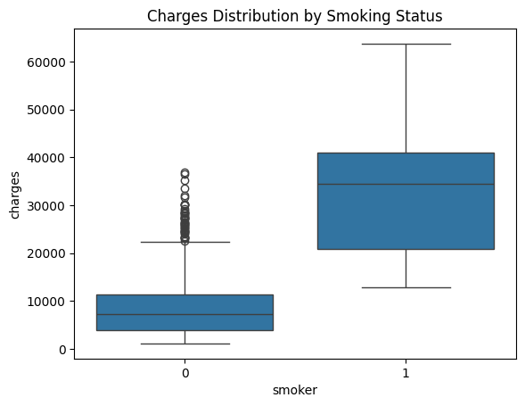

```python
smoker_vs_non_smoker = df.groupby('smoker')['charges'].mean()
print(smoker_vs_non_smoker)
sns.boxplot(x='smoker', y='charges', data=df)
plt.title('Charges Distribution by Smoking Status')
plt.show()
```

### 2. Relationship between BMI and Premiums

**Note:** A higher BMI often correlates with higher charges, especially for smokers.

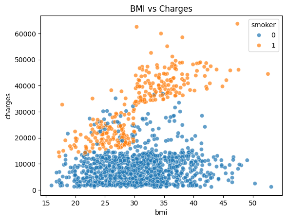

```
Correlation between BMI and Charges: 0.19834096883362878
```

```python
sns.scatterplot(x='bmi', y='charges', hue='smoker', data=df, alpha=0.7)
plt.title('BMI vs Charges')
plt.show()
print("Correlation between BMI and Charges:", df['bmi'].corr(df['charges']))
```

### 3. Regional Differences in Premiums

**Note:** Regional averages help identify geographical patterns in costs.

```
region_northwest  region_southeast  region_southwest
False             False             False               13406.384516
                                    True                12346.937377
                  True              False               14735.411438
True              False             False               12417.575374
Name: charges, dtype: float64
```

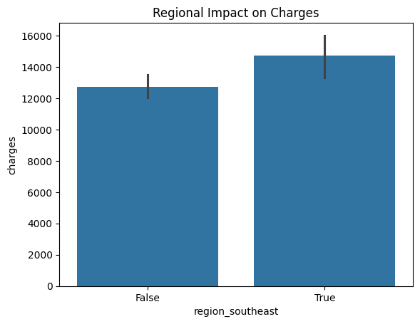

```python
region_charges = df.groupby(['region_northwest','region_southeast','region_southwest']).mean()['charges']
print(region_charges)
sns.barplot(x='region_southeast', y='charges', data=df)
plt.title('Regional Impact on Charges')
plt.show()
```

### 4. Effect of Children on Premiums

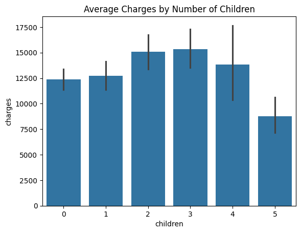

```python
sns.barplot(x='children', y='charges', data=df, estimator=np.mean)
plt.title('Average Charges by Number of Children')
plt.show()
```

### 5. Characteristics of High-Risk Customers

**Note:** High-risk individuals usually combine smoking with high BMI and older age.

```
              age         bmi    children      smoker       charges
count  133.000000  133.000000  133.000000  133.000000    133.000000
mean    41.894737   35.684474    1.233083    0.977444  42435.376422
std     13.518373    4.484903    1.127395    0.149046   5478.380230
min     18.000000   22.895000    0.000000    0.000000  35069.374520
25%     31.000000   32.775000    0.000000    1.000000  38344.566000
50%     43.000000   35.300000    1.000000    1.000000  41661.602000
75%     53.000000   37.800000    2.000000    1.000000  46113.511000
max     64.000000   52.580000    4.000000    1.000000  63770.428010
```

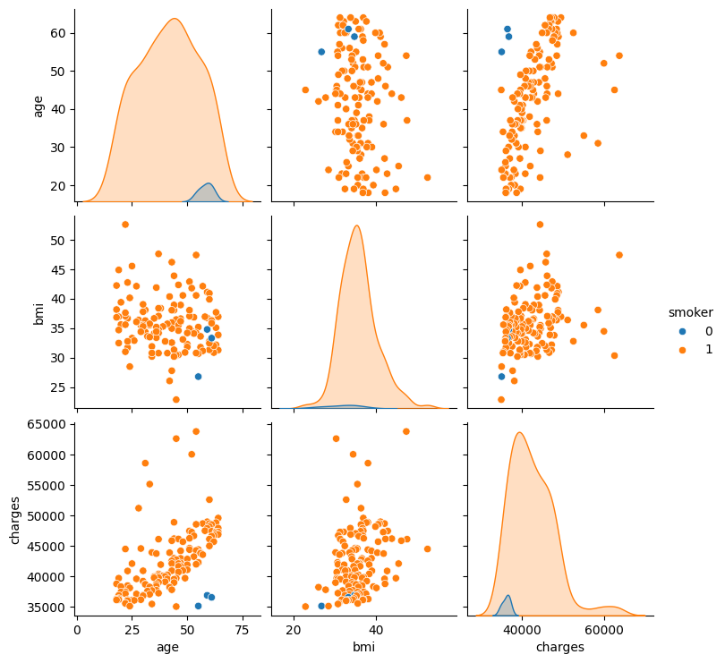

```python
top_10 = df.sort_values(by='charges', ascending=False).head(int(len(df)*0.1))
print(top_10.describe())
sns.pairplot(top_10[['age','bmi','charges','smoker']], hue='smoker')
plt.show()
```

### 6. Correlation Heatmap

**Note:** The heatmap shows how variables are related to each other numerically.

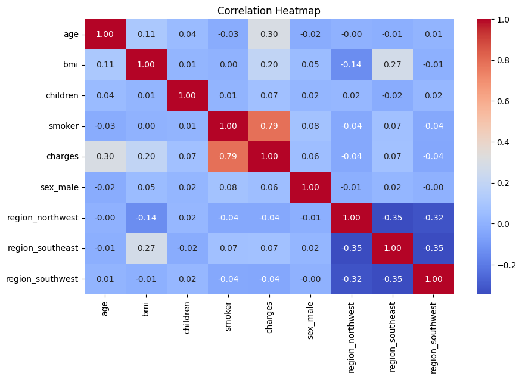

```python
plt.figure(figsize=(10,6))
sns.heatmap(df.corr(), annot=True, cmap='coolwarm', fmt='.2f')
plt.title('Correlation Heatmap')
plt.show()
```

## Conclusion & Recommendations

### Recommendations

1. **Refine Pricing Models:** Incorporate smoking, BMI, and age as core features in risk-based pricing models to ensure premiums reflect actual customer risk.
2. **Targeted Health Programs:** Introduce wellness initiatives such as smoking cessation support and weight management programs. These can both reduce long-term claims and enhance customer loyalty.
3. **Family-Oriented Policies:** Develop family-oriented insurance products with tailored pricing to balance affordability for larger households with risk exposure.
4. **Regional Adjustments:** Consider slight premium adjustments by region to account for localized cost patterns and maintain competitiveness.
5. **Enhanced Data Collection:** Expand data gathering efforts to include lifestyle and medical history variables (e.g., diet, exercise habits, chronic conditions) to improve predictive accuracy and refine future analyses.

**Note:** By combining these insights with proactive health management initiatives, the company can not only mitigate financial risks but also strengthen its market position through fair, transparent, and data-driven pricing strategies.